# Build and deploy a stroke prediction model using R

Lily Tang

2025-01-08

# About The Case Study

This purpose of this case study is to learn and practice the building and deploying a stroke prediction model using R. It is based on a project I discovered on [Coursera](https://www.coursera.org/learn/showcase-build-and-deploy-a-stroke-prediction-model-with-r/home/module/1). It’s a great free resource that I encourage anyone who is interested in learning prediction model to check out. This case study could be a good start as it presents step-by-step how to implement prediction model using R. Use the navigation pane on the left to jump between sections.[^1] If you are interested in further learning, I included all resources I referenced while working on this project. Those are very helpful!

# Data Description:

According to the World Health Organization (WHO) stroke is the 2nd leading cause of death globally, responsible for approximately 11% of total deaths.

This data set is used to predict whether a patient is likely to get stroke based on the input parameters like gender, age, various diseases, and smoking status. Each row in the data provides relevant information about the patient.

# Step One: Import data and data pre-processing

## Load data and install packages

Since I already completed the installation, my code starts with loading these packages. The data is in the csv. format, so I import the data using `read.csv` as `db`.

```r
# Install and load packages needed for analysis
library(tidymodels)
library(workflows)
library(tune)
library(mlbench)
library(ranger)
library(skimr)
library(yardstick)
library(vip)
library(tidyr)
library(dplyr)

# Load stroke data
db <- read.csv("healthcare-dataset-stroke-data.csv")
```

## Describe and explore the data

```r
head(db) # quick look at the data
```

```
##      id gender age hypertension heart_disease ever_married     work_type
## 1  9046   Male  67            0             1          Yes       Private
## 2 51676 Female  61            0             0          Yes Self-employed
## 3 31112   Male  80            0             1          Yes       Private
## 4 60182 Female  49            0             0          Yes       Private
## 5  1665 Female  79            1             0          Yes Self-employed
## 6 56669   Male  81            0             0          Yes       Private
##   Residence_type avg_glucose_level  bmi  smoking_status stroke
## 1          Urban            228.69 36.6 formerly smoked      1
## 2          Rural            202.21  N/A    never smoked      1
## 3          Rural            105.92 32.5    never smoked      1
## 4          Urban            171.23 34.4          smokes      1
## 5          Rural            174.12   24    never smoked      1
## 6          Urban            186.21   29 formerly smoked      1
```

```r
str(db) # check variable type
```

```
## 'data.frame':    5110 obs. of  12 variables:
##  $ id               : int  9046 51676 31112 60182 1665 56669 53882 10434 27419 60491 ...
##  $ gender           : chr  "Male" "Female" "Male" "Female" ...
##  $ age              : num  67 61 80 49 79 81 74 69 59 78 ...
##  $ hypertension     : int  0 0 0 0 1 0 1 0 0 0 ...
##  $ heart_disease    : int  1 0 1 0 0 0 1 0 0 0 ...
##  $ ever_married     : chr  "Yes" "Yes" "Yes" "Yes" ...
##  $ work_type        : chr  "Private" "Self-employed" "Private" "Private" ...
##  $ Residence_type   : chr  "Urban" "Rural" "Rural" "Urban" ...
##  $ avg_glucose_level: num  229 202 106 171 174 ...
##  $ bmi              : chr  "36.6" "N/A" "32.5" "34.4" ...
##  $ smoking_status   : chr  "formerly smoked" "never smoked" "never smoked" "smokes" ...
##  $ stroke           : int  1 1 1 1 1 1 1 1 1 1 ...
```

```r
skim(db) # summarize by variable
```

Data summary

| Name | db |
| --- | --- |
| Number of rows | 5110 |
| Number of columns | 12 |
| _______________________ |  |
| Column type frequency: |  |
| character | 6 |
| numeric | 6 |
| ________________________ |  |
| Group variables | None |

**Variable type: character**

| skim_variable | n_missing | complete_rate | min | max | empty | n_unique | whitespace |
| --- | --- | --- | --- | --- | --- | --- | --- |
| gender | 0 | 1 | 4 | 6 | 0 | 3 | 0 |
| ever_married | 0 | 1 | 2 | 3 | 0 | 2 | 0 |
| work_type | 0 | 1 | 7 | 13 | 0 | 5 | 0 |
| Residence_type | 0 | 1 | 5 | 5 | 0 | 2 | 0 |
| bmi | 0 | 1 | 2 | 4 | 0 | 419 | 0 |
| smoking_status | 0 | 1 | 6 | 15 | 0 | 4 | 0 |

**Variable type: numeric**

| skim_variable | n_missing | complete_rate | mean | sd | p0 | p25 | p50 | p75 | p100 | hist |
| --- | --- | --- | --- | --- | --- | --- | --- | --- | --- | --- |
| id | 0 | 1 | 36517.83 | 21161.72 | 67.00 | 17741.25 | 36932.00 | 54682.00 | 72940.00 | ▇▇▇▇▇ |
| age | 0 | 1 | 43.23 | 22.61 | 0.08 | 25.00 | 45.00 | 61.00 | 82.00 | ▅▆▇▇▆ |
| hypertension | 0 | 1 | 0.10 | 0.30 | 0.00 | 0.00 | 0.00 | 0.00 | 1.00 | ▇▁▁▁▁ |
| heart_disease | 0 | 1 | 0.05 | 0.23 | 0.00 | 0.00 | 0.00 | 0.00 | 1.00 | ▇▁▁▁▁ |
| avg_glucose_level | 0 | 1 | 106.15 | 45.28 | 55.12 | 77.24 | 91.88 | 114.09 | 271.74 | ▇▃▁▁▁ |
| stroke | 0 | 1 | 0.05 | 0.22 | 0.00 | 0.00 | 0.00 | 0.00 | 1.00 | ▇▁▁▁▁ |

The `ggplot()` function provides great visualization of variable’s distribution and makes it easy to spot any outliers. Here I use the function to review stroke, age and average glucose level distributions. We can observe an imbalanced distribution in variable stroke.

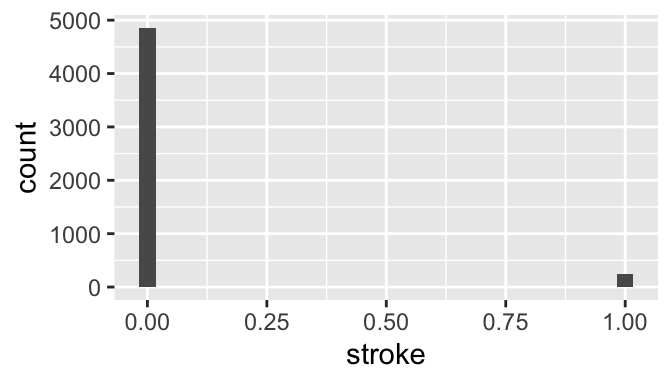

```r
ggplot(db) +
  geom_histogram(aes(x = stroke))
```

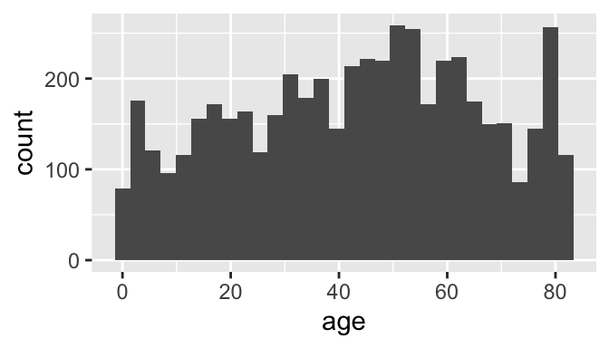

```r
ggplot(db) +
  geom_histogram(aes(x = age))
```

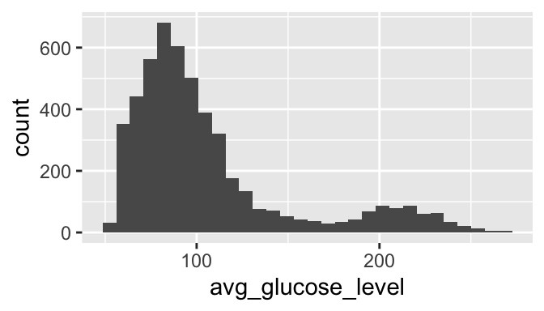

```r
ggplot(db) +
  geom_histogram(aes(x = avg_glucose_level))
```

## Data preparation

Based on findings from the above steps, I need to adjust the original data to prepare for the following steps. For example, all categorical variables need to be converted to “dummy variable”. And, we need to convert `bmi` from categorical to numeric to prevent it from also being converted. Furthermore, the outcome variable `stroke` needs to be converted from integer to factor to accommodate the modelling stage. Additionally, I adjust the levels of the factor to set value “1” as the reference value, representing the occurrence of stroke. The prepared data is stored in `db_clean`.

In some instances[^2], the data would contain zero or other values that don’t make much sense, it could imply that that missing observations are recorded as those values. If this is the case, additional steps are needed to replace them with NAs.

```r
db_clean <- db %>%
  # convert bmi and stroke to the desired data type
  mutate(bmi = as.numeric(bmi), stroke = as.factor(stroke))

# re-level stroke variable
db_clean$stroke <- relevel(db_clean$stroke, ref = "1")
```

# Step Two: Build prediction models

As an essential step of prediction models, splitting the data will create a *training* set and *test* set. The *training* set will be used to fit the model and the *test* set will be used assess the model performance through several measurements. In this case study, `inintal_split` function splits 75% of the data into *training* set and the rest 25% into *test* set. There is an imbalanced distribution in variable `stroke` observed in the earlier step, so here I use the `strata` argument to keep consistent the proportions of stroke between data set and the original data. Before splitting the data, I apply `set.seed()` function to ensure reproducible results.

```r
set.seed(234589)
db_split <- initial_split(db_clean, prop = 3/4, strata = stroke)
db_split
```

```
## <Training/Testing/Total>
## <3832/1278/5110>
```

```r
# extract training and testing sets
db_train <- training(db_split)
db_test <- testing(db_split)
```

## Build recipe

“Recipe” is a series of pre-processing steps to prepare the data for the model. There are a number of useful recipe steps that help create the specification of the recipe. More specifically, recipe can be used across several steps of the model training and testing as summarized below:[^3]

1. **Specify formula**: This sets the outcome variable and predictor variables.
2. **Process the recipe using the training set**: This prepares the *training* set, such as converting factor predictor to dummy variables.
3. **Apply the recipe to the training set:** This creates a final predictor set on the *training* set.
4. **Apply the recipe to the test set**: This applies on the *test* set the final predictor resulted from the *training* set.

Below, I set `stroke` as the outcome variable and the remaining variables separated be `~` as predictors. If we want to include all variables (other than the outcome variable) as the predictor, using `.` is a convenient way. Then, I use `step_dummy()` function to convert nominal data into numeric binary data. `step_zv()` removes variables (column) that only contain a single unique value (e.g. all zeros). The `summary()` function outputs variable type, role (outcome or predictor) and source.

```r
db_recipe <-
  recipe(stroke ~ gender + age + hypertension + heart_disease + ever_married + work_type + Residence_type + avg_glucose_level + bmi + smoking_status,
         data = db_clean) %>%
  # and some pre-processing
  step_dummy(all_factor_predictors()) %>%
  step_zv(all_predictors())
summary(db_recipe)
```

```
## # A tibble: 11 × 4
##    variable          type      role      source
##    <chr>             <list>    <chr>     <chr>
##  1 gender            <chr [3]> predictor original
##  2 age               <chr [2]> predictor original
##  3 hypertension      <chr [2]> predictor original
##  4 heart_disease     <chr [2]> predictor original
##  5 ever_married      <chr [3]> predictor original
##  6 work_type         <chr [3]> predictor original
##  7 Residence_type    <chr [3]> predictor original
##  8 avg_glucose_level <chr [2]> predictor original
##  9 bmi               <chr [2]> predictor original
## 10 smoking_status    <chr [3]> predictor original
## 11 stroke            <chr [3]> outcome   original
```

I am curious about the pre-processed data so below is a quick check on the result from applying the recipe to the *training* data. It is not necessary step though.

```r
db_train_preprocessed <- db_recipe %>%
  prep(db_train) %>% juice()
```

It is worth mentioning that I noticed the order of the steps sometimes affects the success of running the code. The content [here](https://cran.r-project.org/web/packages/recipes/vignettes/Ordering.html) shares some general suggestions that I find helpful.

In the next steps, I will experiment two types of models and combine them with the recipe created from above to create a workflow.

## The Regression Approach

Because the outcome variable `stroke` is binary, a simple logistic regression model is selected.

```r
rg_mod <-
  logistic_reg() %>%
  set_engine("glm")
```

Here I combine recipe and model into workflow.

```r
rg_workflow <- workflow() %>%
  # add recipe
  add_recipe(db_recipe) %>%
  # add model
  add_model(rg_mod)
```

Now I use the workflow to train the model on the *training* set.

```r
rg_fit <-
  rg_workflow %>%
  fit(data = db_train)
```

The object `rg_fit` contains the finalized recipe and fitted model objects. The resulting predictor can be extracted using `extract_fit_parsnip()` and visualized using the `vip` package. This step’s results suggest that `age`, `hypertension` and `average glucose level` are top three most important predictors for stroke.

```r
# extract
rg_fit %>%
  extract_fit_parsnip() %>%
  tidy()
```

```
## # A tibble: 17 × 5
##    term                       estimate  std.error statistic  p.value
##    <chr>                         <dbl>      <dbl>     <dbl>    <dbl>
##  1 (Intercept)                 7.01       1.09      6.45    1.12e-10
##  2 genderMale                 -0.00803    0.179    -0.0449  9.64e- 1
##  3 genderOther                11.3     2400.        0.00469 9.96e- 1
##  4 age                        -0.0742     0.00739 -10.0     1.00e-23
##  5 hypertension               -0.545      0.203    -2.68    7.27e- 3
##  6 heart_disease              -0.256      0.248    -1.03    3.01e- 1
##  7 ever_marriedYes             0.0501     0.296     0.169   8.66e- 1
##  8 work_typeGovt_job           1.05       1.16      0.910   3.63e- 1
##  9 work_typeNever_worked      11.1      597.        0.0186  9.85e- 1
## 10 work_typePrivate            0.836      1.14      0.735   4.62e- 1
## 11 work_typeSelf-employed      1.18       1.16      1.02    3.07e- 1
## 12 Residence_typeUrban         0.0371     0.174     0.213   8.31e- 1
## 13 avg_glucose_level          -0.00326    0.00152  -2.14    3.24e- 2
## 14 bmi                        -0.00629    0.0139   -0.453   6.50e- 1
## 15 smoking_statusnever smoked  0.0953     0.216     0.441   6.59e- 1
## 16 smoking_statussmokes       -0.0357     0.281    -0.127   8.99e- 1
## 17 smoking_statusUnknown       0.236      0.276     0.853   3.94e- 1
```

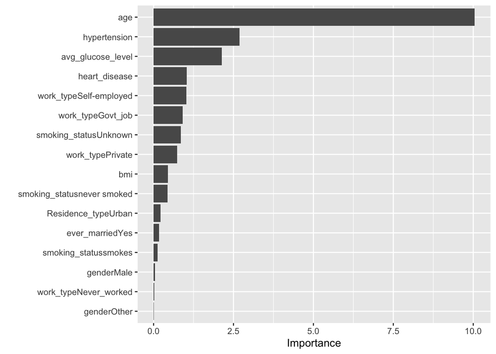

```r
# visualize using Variable Importance Plots
rg_fit %>%
  extract_fit_parsnip() %>%
  vip(num_features = 20)
```

To get the predicted class probabilities for each observation, I use `augment()` function to predict the test data. The prediction is stored in the `rg_test_predictions` object.

```r
rg_test_predictions <-
  augment(rg_fit, db_test)
```

An alternative way for `augment` is using `bind_cols`, as shown below:

```r
alt_aug <- predict(rg_fit, db_test) %>%
  bind_cols(predict(rg_fit, db_test, type = "prob")) %>%
  # add the test data
  bind_cols(db_test %>% select(stroke)) %>%
    select(stroke, .pred_class,.pred_0, .pred_1)
```

## The Random Forest Approach

Apart from the regression model, we can apply a random forest model for prediction. I start with a 10-fold cross-validation method using `vfold_cv`. This method creates 10 different resamples within the *training* set, further splitting into analysis and assessment sets, resulting in 10 different performance metrics and aggregates them.[^4]

```r
set.seed(345)
db_cv <- vfold_cv(db_train)
db_cv
```

```
## #  10-fold cross-validation
## # A tibble: 10 × 2
##    splits             id
##    <list>             <chr>
##  1 <split [3448/384]> Fold01
##  2 <split [3448/384]> Fold02
##  3 <split [3449/383]> Fold03
##  4 <split [3449/383]> Fold04
##  5 <split [3449/383]> Fold05
##  6 <split [3449/383]> Fold06
##  7 <split [3449/383]> Fold07
##  8 <split [3449/383]> Fold08
##  9 <split [3449/383]> Fold09
## 10 <split [3449/383]> Fold10
```

Here, I use the `tune` package to examine a series of values that assign the number of randomly selected variable to be considered at each split in the trees. The parameter `mtry` will be tuned at a later stage of the pipeline and the parameter that yields the best performance will be selected for the final model. I also use the `ranger` package to evaluate the importance of variables in my final model. The importance options are `impurity` and `permutation`. [^5]

```r
# specifying model (random forest)
set.seed(234)
rf_mod <-
  rand_forest() %>%
  # specify that the `mtry` parameter needs to be tuned
  set_args(mtry = tune()) %>%
  # select the engine/package that underlies the model
  set_engine("ranger", importance = "impurity") %>%
  # choose either the continuous regression or binary classification mode
  set_mode("classification")
```

Same as the regression approach, here I combine recipe and model into workflow.

```r
# show parameter to be tuned
extract_parameter_set_dials(rf_mod)
```

```
## Collection of 1 parameters for tuning
##
##  identifier type    object
##        mtry mtry nparam[?]
##
## Model parameters needing finalization:
##    # Randomly Selected Predictors ('mtry')
##
## See `?dials::finalize` or `?dials::update.parameters` for more information.
```

```r
# set workflow
rf_workflow <- workflow() %>%
  # add recipe
  add_recipe(db_recipe) %>%
  # add model
  add_model(rf_mod)
```

Here I use `expand.grid()` to specify the values of `mtry` that I want to examine. The `tune_grid()` from the `tune` package allows me to add a tuning layer to the workflow. The tuning uses the cross-validation object `db_cv` created earlier. We will focus on `accuracy` and `roc_auc` from the `yardstick` package to determine the best `mtry` value. However, this is not a necessary step to create the workflow.

```r
# specify values to tune
# mtry <- sqrt(ncol(x))
rf_grid <- expand.grid(mtry = c(3:5))

# extract tuning results
rf_tune_results <- rf_workflow %>%
  tune_grid(resamples = db_cv,
            grid = rf_grid,
            control = control_grid(save_pred = TRUE),
            metrics = metric_set(accuracy, roc_auc)
            )
```

Similar to the `augment()` function, we can explore the cross-validation results using the `collect_metrics()` function. It extracts any metrics that have been calculated within the object it’s being used on (with the `tune_grid()` function only). The `select_best()` function simply outputs the `mtry` value yields the best performance based on the `metric` argument.

```r
rf_tune_results %>%
  collect_metrics()
```

```
## # A tibble: 6 × 7
##    mtry .metric  .estimator  mean     n std_err .config
##   <int> <chr>    <chr>      <dbl> <int>   <dbl> <chr>
## 1     3 accuracy binary     0.952    10 0.00259 Preprocessor1_Model1
## 2     3 roc_auc  binary     0.806    10 0.0179  Preprocessor1_Model1
## 3     4 accuracy binary     0.952    10 0.00268 Preprocessor1_Model2
## 4     4 roc_auc  binary     0.810    10 0.0173  Preprocessor1_Model2
## 5     5 accuracy binary     0.952    10 0.00259 Preprocessor1_Model3
## 6     5 roc_auc  binary     0.807    10 0.0165  Preprocessor1_Model3
```

```r
best_param <- rf_tune_results %>%
  select_best(metric = "roc_auc")
best_param
```

```
## # A tibble: 1 × 2
##    mtry .config
##   <int> <chr>
## 1     4 Preprocessor1_Model2
```

Now we can add the layer to the worklow to reflect the tuned parameter using `finalize_workflow()` function.

```r
# print results
rf_last_workflow <- rf_workflow %>%
  finalize_workflow(best_param)
```

Now all he workflow is finally specified with all necessary information, I will use the `last_fit()` function to train the model. The function does the following two things:

1. Fit the *training* set and,
2. Generate evaluations based on the *test* set

Here I use the `collect_metrics()` function again to extract the performance of the final model applied to the *test* set. We can also use `collect_predictions()` function to extract the *test* set predictions.

```r
# evaluate on the test set
rf_last_fit <- rf_last_workflow %>%
  last_fit(db_split)

rf_last_fit %>% collect_metrics()
```

```
## # A tibble: 3 × 4
##   .metric     .estimator .estimate .config
##   <chr>       <chr>          <dbl> <chr>
## 1 accuracy    binary        0.948  Preprocessor1_Model1
## 2 roc_auc     binary        0.818  Preprocessor1_Model1
## 3 brier_class binary        0.0459 Preprocessor1_Model1
```

```r
# generate predictions from the test set
rf_test_predictions <- rf_last_fit %>% collect_predictions()
rf_test_predictions
```

```
## # A tibble: 1,278 × 7
##    .pred_class .pred_1 .pred_0 id                .row stroke .config
##    <fct>         <dbl>   <dbl> <chr>            <int> <fct>  <chr>
##  1 0            0.149    0.851 train/test split     1 1      Preprocessor1_Mode…
##  2 0            0.199    0.801 train/test split     3 1      Preprocessor1_Mode…
##  3 0            0.201    0.799 train/test split    12 1      Preprocessor1_Mode…
##  4 0            0.0232   0.977 train/test split    13 1      Preprocessor1_Mode…
##  5 0            0.169    0.831 train/test split    14 1      Preprocessor1_Mode…
##  6 0            0.0831   0.917 train/test split    15 1      Preprocessor1_Mode…
##  7 0            0.0847   0.915 train/test split    19 1      Preprocessor1_Mode…
##  8 0            0.169    0.831 train/test split    21 1      Preprocessor1_Mode…
##  9 0            0.280    0.720 train/test split    33 1      Preprocessor1_Mode…
## 10 0            0.219    0.781 train/test split    34 1      Preprocessor1_Mode…
## # ℹ 1,268 more rows
```

# Step Three: Evaluate and select prediction models

To evaluate model performance, I used the area under the Receiver Operating Characteristic (ROC) curve.

First, I evaluate the ROC of the logistic regression model using the `rg_test_predictions` object created earlier.

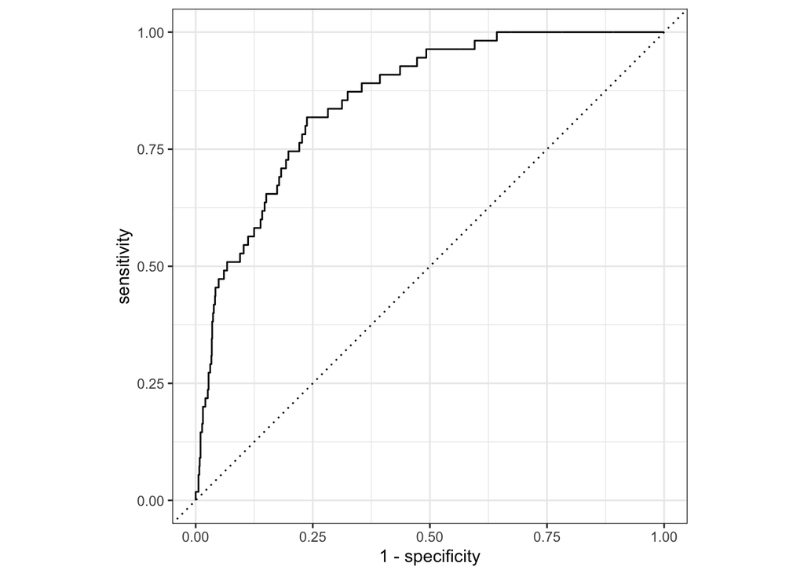

```r
# generate ROC curve
rg_test_predictions %>%
  roc_curve(truth = stroke,.pred_1) %>%
  autoplot
```

```r
# generate AUC
rg_auc <- rg_test_predictions %>%
  roc_auc(truth =
              stroke,.pred_1)
rg_auc
```

```
## # A tibble: 1 × 3
##   .metric .estimator .estimate
##   <chr>   <chr>          <dbl>
## 1 roc_auc binary         0.856
```

The model has an AUC of 0.856204.

Similarly, the ROC of the random forest model is generated.

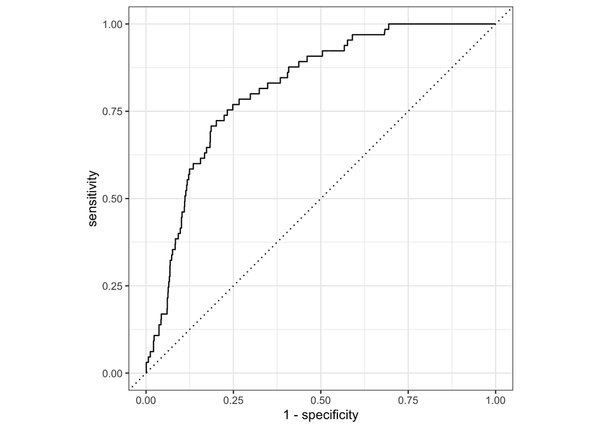

```r
# generate ROC curve
rf_test_predictions %>%
  roc_curve(truth = stroke,.pred_1) %>%
  autoplot
```

```r
# generate AUC
rf_auc <- rf_test_predictions %>%
  roc_auc(truth =
              stroke,.pred_1)
rf_auc
```

```
## # A tibble: 1 × 3
##   .metric .estimator .estimate
##   <chr>   <chr>          <dbl>
## 1 roc_auc binary         0.818
```

The model has an AUC of 0.8176549.

Now, we can combine both ROC curves using `ggplot()` function.

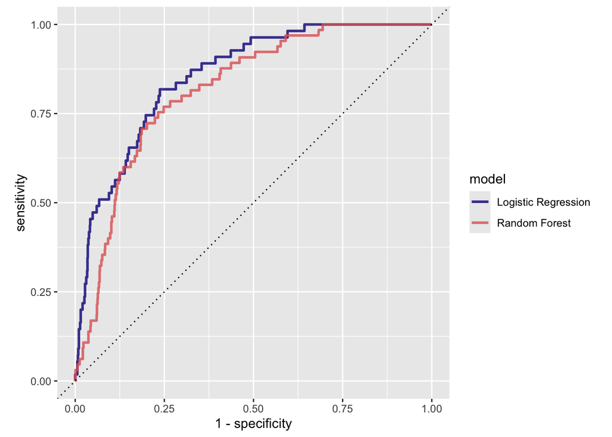

```r
rf_auc <-
  rf_last_fit %>%
  collect_predictions() %>%
  roc_curve(stroke, .pred_1) %>%
  mutate(model = "Random Forest")

rg_auc <-
  rg_test_predictions %>%
  roc_curve(stroke, .pred_1) %>%
  mutate(model = "Logistic Regression")

bind_rows(rf_auc, rg_auc) %>%
  ggplot(aes(x = 1 - specificity, y = sensitivity, col = model)) +
  geom_path(lwd = 1, alpha = 0.8) +
  geom_abline(lty = 3) +
  coord_equal() +
  scale_color_viridis_d(option = "plasma", end = .6)
```

We can also compare the confusion matrix and probability distributions for both models.

```r
# generate a confusion matrix for logistic regression model
rg_test_predictions %>%
  conf_mat(truth = stroke, estimate = .pred_class)
```

[output not shown]

```r
# generate a confusion matrix for random forest model
rf_test_predictions %>%
  conf_mat(truth = stroke, estimate = .pred_class)
```

```
##           Truth
## Prediction    1    0
##          1    0    1
##          0   65 1212
```

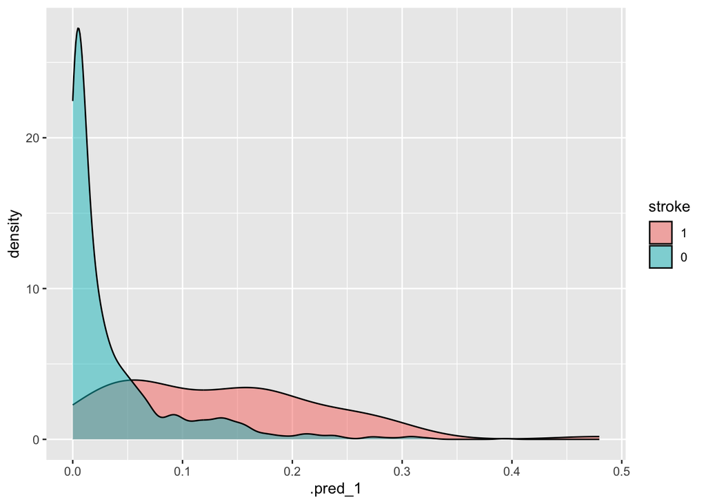

```r
# plot probability distribution for logistic regression model
rg_test_predictions %>%
  ggplot() +
  geom_density(aes(x = .pred_1, fill = stroke),
               alpha = 0.5)
```

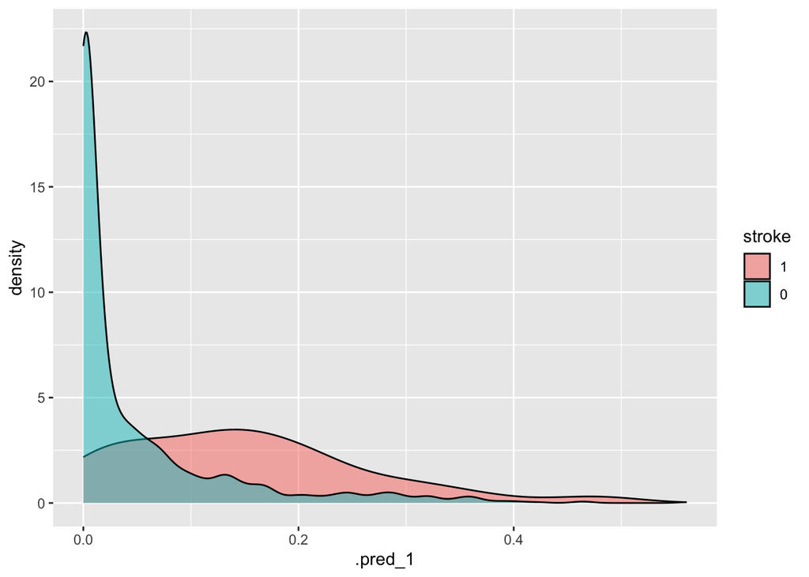

```r
# plot probability distribution for random forest model
rf_test_predictions %>%
  ggplot() +
  geom_density(aes(x = .pred_1, fill = stroke),
               alpha = 0.5)
```

Two models have similar curves, but the logistic model yields a higher AUC value. Therefore, the logistic model has slightly better performance compared to the random forest model.

# Step Four: Deploy the prediction model

We have now selected the logistic regression model as the final model, the next step is to fit the model on the full set of data (`db_clean`). We will use `fit()` functions as introduces earlier.

```r
# use final model to fit the full data
final_model <- fit(rg_workflow, db_clean)
```

We can also use the `final_model` to predict the stroke status on a unseen data using the `predict` function.

```r
# create new data
new_stroke <- tribble(~gender, ~age, ~hypertension, ~heart_disease, ~ever_married, ~work_type, ~Residence_type, ~avg_glucose_level, ~bmi, ~smoking_status,
                     "Female", 80,    0,             0,              "Yes",             "Private",  "Urban",         105.92,             23.5, "never smoked")
new_stroke
```

```
## # A tibble: 1 × 10
##   gender   age hypertension heart_disease ever_married work_type Residence_type
##   <chr>  <dbl>        <dbl>         <dbl> <chr>        <chr>     <chr>
## 1 Female    80            0             0 Yes          Private   Urban
## # ℹ 3 more variables: avg_glucose_level <dbl>, bmi <dbl>, smoking_status <chr>
```

```r
# predict new data
predict(final_model, new_data = new_stroke)
```

```
## # A tibble: 1 × 1
##   .pred_class
##   <fct>
## 1 0
```

The predicted stroke status of this new data is 0, meaning no stroke.

# Findings and Conclusions

Prediction model is a powerful tool to predict outcomes in a new data set using model trained by the existing data. This case study presents an example of building the deploying a stroke prediction model using R, and I believe many aspects of this project can be improved. For example, I am sure the random forest model’s performance can be optimized besides tuning a single parameter. Additionally, the probability distribution plot is skewed, suggesting that even the selected model with better comparative performance can be further improved.

[^1]: https://bookdown.org/yihui/rmarkdown/html-document.html#
[^2]: [Tidymodels: tidy machine learning in R](https://rebeccabarter.com/blog/2020-03-25_machine_learning)
[^3]: https://www.tidymodels.org/start/recipes/#recipe
[^4]: https://www.tidymodels.org/start/case-study/
[^5]: https://rebeccabarter.com/blog/2020-03-25_machine_learning